# The second part

У нас есть 304 валидных агента из файла contracted_agents и 881 уникальный логин в файле sales_jan_jul. Начнём с общего обзора данных по продажам — сводной таблицы по продажам и лидам. Затем перейдём к анализу агентов, по которым у нас есть информация.

|  | Total profit | Sales Count | Leads Taken |
| --- | --- | --- | --- |
| mean | 6.152326 | 1.223072 | 212.995421 |
| std | 8.344309 | 0.558375 | 247.285363 |
| min | -5.569839 | 1.000000 | 1.000000 |
| 25% | 1.418392 | 1.000000 | 33.000000 |
| 50% | 3.782100 | 1.000000 | 134.000000 |
| 75% | 7.674975 | 1.000000 | 316.000000 |
| max | 140.127120 | 15.000000 | 4652.000000 |

В таблице выше Leads Taken отражает статистику лидов, полученных в среднем агентом за месяц (судя по файлу assigned_leads). А вот показатели Total profit и Sales Count — это показатели по дням (судя по sales_jan_jul) в среднем, по агенту в те дни, когда у него была хотя бы одна продажа. Дни без продаж не учитываются.

Если учитывать все дни из таблицы sales_jan_jul за период с 01.01.2024 по 31.07.2024, включая и те, когда у агента не было продаж, то **в среднем на одного агента приходится около 0.05 продаж в день и $0.26 прибыли в день.**

Также можно заметить, что медиана (50-й процентиль) и максимум в столбце Leads Taken значительно различаются. Это указывает на неравномерное распределение лидов. И **есть явно выраженный выброс — строка "va380, 2024-05" со значением "Leads Taken" - 4652**, следующие по значению — 2957 и 2499. Далее значения убывают более плавно.

Выделим топ-10 агентов по количеству продаж и топ-10 с наименьшими результатами.

Top 10

| Login | Sales Count |
| --- | --- |
| am212 | 103 |
| vk659 | 99 |
| ap168 | 81 |
| np100 | 81 |
| mb151 | 80 |
| em142 | 80 |
| sm1123 | 74 |
| ak124 | 72 |
| gg100 | 71 |
| sa159 | 71 |

Bottom 10

| Login | Sales Count |
| --- | --- |
| mm1730 | 1 |
| nb621 | 1 |
| my277 | 1 |
| mv339 | 1 |
| ms3181 | 1 |
| ms1898 | 1 |
| mr1304 | 1 |
| mp321 | 1 |
| mp100 | 1 |
| mk1737 | 1 |

Ниже представлена таблица с топ-10 агентами, получившими наибольшее количество лидов, и топ-10 с наименьшим числом полученных лидов.

Top 10

| Login | Leads Taken |
| --- | --- |
| vr209 | 11004 |
| va380 | 8301 |
| ak1020 | 6887 |
| hm339 | 6297 |
| mg524 | 6071 |
| ss5550 | 5772 |
| jp246 | 5532 |
| bo117 | 5202 |
| al448 | 5029 |
| dk593 | 4884 |

Bottom 10

| Login | Leads Taken |
| --- | --- |
| sm2315 | 1 |
| ak1762 | 1 |
| kr171 | 1 |
| mb627 | 1 |
| ja500 | 1 |
| ss5739 | 1 |
| sk3877 | 1 |
| pn306 | 1 |
| mb890 | 1 |
| hs952 | 1 |

Можно ещё заметить, что **ни одного агента из топ-10 по продажам нет в топ-10 по предоставленным лидам**. Первое вхождение кого-то из топ-10 агентов по продажам это у агента из 9 строчки по продажам "gg100", и он на 162 месте по количеству предоставленных лидов, из 2436 агентов, кому предоставили какое-либо количество лидов.

В таблице с продажами по какой-то причине присутствуют 13 логинов, которых нет в таблице выдачи лидов. Из 881 логина в sales_jan_jul, только 868 присутствуют в assigned_leads. Предположительно, часть агентов получила лиды до первой даты в assigned_leads, либо это ошибка в данных. Тем не менее, если по этим данным рассчитать стоимость одной продажи в лидах, то **в среднем требуется 133 лида, чтобы совершить одну продажу, которая в среднем приносит $5 прибыли (Total profit)**.

Посмотрим на общее распределение продаж: сколько агентов сделали определённое количество продаж.

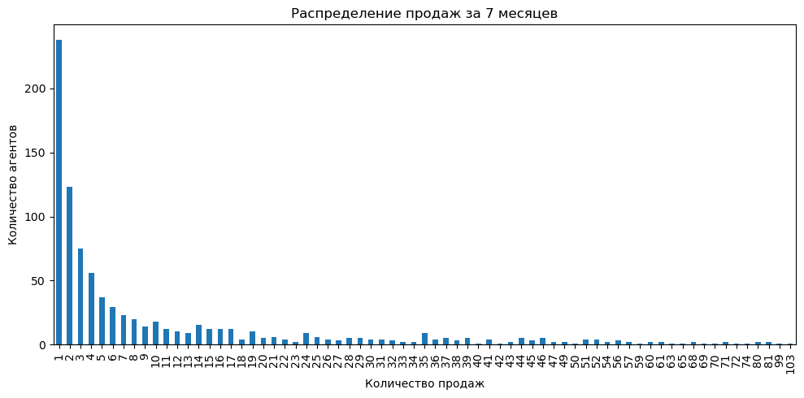

Как видно из графика, подавляющее большинство агентов — **примерно 56% — сделали не более 4 продаж за 7 месяцев**. Это может говорить о том, что значительная часть агентов прекратила работу практически сразу после начала.

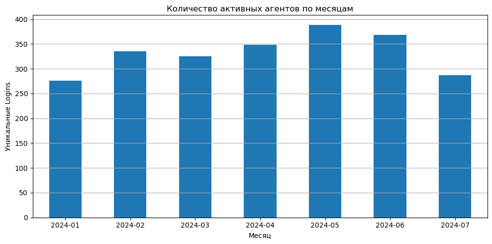

До мая наблюдалась относительно положительная динамика по числу активных агентов, однако с мая по июль количество агентов начало снижаться, особенно заметно падение с июня по июль.

Можно предположить, что новые сотрудники склонны быстро уходить, возможно из-за недостаточного количества получаемых лидов в начале. Проверим эту гипотезу на новых агентах из contracted_agents, подписавших контракт как раз перед началом периода sales_jan_jul. Посмотрим, как меняется среднее количество полученных лидов в зависимости от времени работы по месяцам.

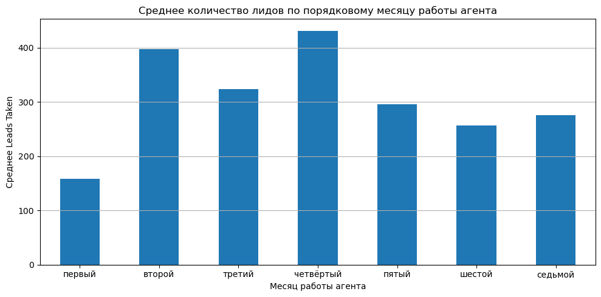

Как видно из данных, **в первый месяц работы агенты получают в среднем в 2 раза меньше лидов, чем в последующие месяцы**. Вероятно, это и объясняет, почему почти половина агентов прекращают работу уже после первого месяца. Ниже представлена таблица, показывающая, сколько месяцев проработали агенты из contracted_agents.

| Month Number | 1 | 2 | 3 | 4 | 5 | 6 | 7 |
| --- | --- | --- | --- | --- | --- | --- | --- |
| count | 212 | 108 | 73 | 38 | 33 | 28 | 19 |

Из 304 валидных агентов в contracted_agents только 212 получили лидов для обработки по данным из assigned_leads. Это означает, что около 30% агентов так и не начали работу, несмотря на подписанный контракт. Контракты у всех были подписаны в декабре 2023 года или январе 2024, а продажи — за первые 7 месяцев 2024. Вероятно, этим агентам либо не предоставили лидов, либо они отказались работать после подписания контракта. Попробуем выяснить, есть ли связь между этим фактом и разницей между датой подачи заявления и датой подписания контракта (по данным из contracted_agents).

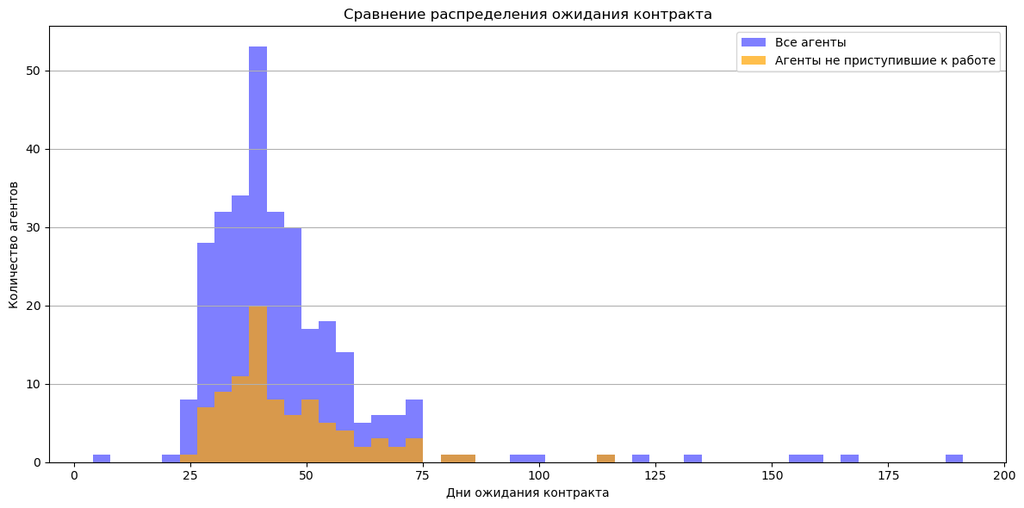

Судя по распределению, явно выраженной корреляции не наблюдается: **количество дней ожидания подписания контракта не влияет на то, получил ли агент в итоге лиды. Также нет зависимости от источника рекламы и уровня образования — агенты без лидов представлены во всех группах**.

Перейдём к общему анализу данных по агентам.

| Education Level | Bachelor | College | Masters | Professional | School | Doctorate |
| --- | --- | --- | --- | --- | --- | --- |
| count | 135 | 71 | 45 | 32 | 11 | 2 |

| Country of Residence | India | Nigeria | Pakistan | Uzbekistan | Moldova |
| --- | --- | --- | --- | --- | --- |
| count | 291 | 6 | 3 | 3 | 1 |

| Source of Advertisement | facebook | Google | linkedin | HRM | DPTR | instagram_bio | indeed | fecebook_bot |
| --- | --- | --- | --- | --- | --- | --- | --- | --- |
| count | 151 | 126 | 9 | 8 | 4 | 2 | 2 | 2 |

Рассмотрим сводные данные по агентам и проанализируем, как среднее количество продаж на одного человека за 7 месяцев зависит от источника рекламы и уровня образования. (Столбец "Country of Residence" исключаем из анализа, так как почти все агенты — из Индии.)

| Education Level | Bachelor | College | Masters | Professional | School | Doctorate |
| --- | --- | --- | --- | --- | --- | --- |
| Average Sales | 10.64 | 7.44 | 13.27 | 10.31 | 20.5 | NaN |

| Source of Advertisement | facebook | Google |
| --- | --- | --- |
| Average Sales | 12.12 | 9.3 |

Итого: **из 304 валидных агентов из contracted_agents, только 212 получили лидов, и лишь 93 из них совершили хотя бы одну продажу**.